# R Notebook

Importation des données :

```r
library(readr)
library(dplyr)
Data=read_csv("Notes.csv") #On récupère le csv dans la variable Data qui contiendra TOUTES les données
typeof(Data$Math)
```

```
[1] "double"
```

```r
NoteGenre=Data[2:7] #On retire seulement le nom des élèves
Notes=Data[2:6] #On retire la première colonne avec le nom des élèves pour ne se focaliser que sur les notes
Data
```

| Eleve | Math | Physique | HistGeo | Litterature | EPS | Genre |
| --- | --- | --- | --- | --- | --- | --- |
| Eleve 1 | 15 | 17 | 12 | 12 | 13 | GARCON |
| Eleve 2 | 12 | 10 | 11 | 11 | 14 | GARCON |
| Eleve 3 | 7 | 7 | 13 | 12 | 10 | GARCON |
| Eleve 4 | 10 | 11 | 17 | 16 | 9 | FILLE |
| Eleve 5 | 6 | 8 | 10 | 9 | 17 | GARCON |
| Eleve 6 | 7 | 5 | 8 | 7 | 18 | GARCON |
| Eleve 7 | 15 | 14 | 10 | 12 | 8 | GARCON |
| Eleve 8 | 2 | 3 | 6 | 5 | 17 | GARCON |
| Eleve 9 | 15 | 13 | 14 | 14 | 12 | FILLE |
| Eleve 10 | 17 | 18 | 16 | 18 | 14 | FILLE |

[output cut: 50 more lines]

Separation de chaque matière en vecteurs :

```r
NotesMath=as.numeric(unlist(Notes["Math"]))
NotesPhysique=as.numeric(unlist(Notes["Physique"]))
NotesHistGeo=as.numeric(unlist(Notes["HistGeo"]))
NotesLitterature=as.numeric(unlist(Notes["Litterature"]))
NotesEPS=as.numeric(unlist(Notes["EPS"]))
```

1. Matrices de Covariance/Correlation et regression linéaire

Le but est de trouver une correlation entre les notes des differentes matières Affichage du dataset puis de la matrice de covariance

```r
cov(Notes)
```

```
                 Math   Physique   HistGeo Litterature        EPS
Math        21.812429 20.7615819  9.639548   8.3661017 -1.0734463
Physique    20.761582 21.6768362 11.063277   9.1457627 -0.5480226
HistGeo      9.639548 11.0632768 13.765819   9.8457627 -1.5522599
Litterature  8.366102  9.1457627  9.845763  10.5525424 -0.6186441
EPS         -1.073446 -0.5480226 -1.552260  -0.6186441 14.0437853
```

On préfèrera la matrice de correlation : proche de -1 = variables opposées, proche de 0 = variables non corrélées, proches de 1 = variables identiques

```r
cor(Notes)
```

```
                   Math    Physique    HistGeo Litterature         EPS
Math         1.00000000  0.95479574  0.5562930  0.55143277 -0.06133187
Physique     0.95479574  1.00000000  0.6404494  0.60470482 -0.03140931
HistGeo      0.55629303  0.64044937  1.0000000  0.81690167 -0.11164038
Litterature  0.55143277  0.60470482  0.8169017  1.00000000 -0.05081831
EPS         -0.06133187 -0.03140931 -0.1116404 -0.05081831  1.00000000
```

On remarque qu’il y a une forte correlation entre les maths et la physique, ainsi qu’entre l’histoire/geo et le français d’une moindre manière. Il n’y a par contre une correlation d’aucune matière avec l’EPS.

Grace à la régression linéaire, on peut tenter d’estimer la note d’EPS par exemple en fonction des autres notes.

```r
NotesregEPS=lm(EPS~Math+Physique+HistGeo+Litterature, data=Data)
summary(NotesregEPS)
```

```
Call:
lm(formula = EPS ~ Math + Physique + HistGeo + Litterature, data = Data)

Residuals:
    Min      1Q  Median      3Q     Max
-11.663  -1.342   0.400   1.643   6.842

Coefficients:
            Estimate Std. Error t value Pr(>|t|)
(Intercept)  13.0743     1.8368   7.118 2.42e-09 ***
Math         -0.4029     0.3690  -1.092    0.280
Physique      0.4503     0.3990   1.128    0.264
HistGeo      -0.3004     0.2510  -1.196    0.237
Litterature   0.1508     0.2699   0.559    0.579
---
Signif. codes:  0 ‘***’ 0.001 ‘**’ 0.01 ‘*’ 0.05 ‘.’ 0.1 ‘ ’ 1

Residual standard error: 3.803 on 55 degrees of freedom
Multiple R-squared:  0.03978,   Adjusted R-squared:  -0.03005
F-statistic: 0.5696 on 4 and 55 DF,  p-value: 0.6857
```

On peut établir une fonction de regression linéaire qui est NoteEPS = 13,0743 - 0,4 x NoteMath+0,4 x NotePhysique - 0,3 x NoteHistGeo + 0,15 x NoteLitterature. Ce résultat montre qu’en fait la note d’EPS est relativement peu dépendante des autres notes. Il est donc difficile de prédire une note d’EPS. Par contre si nous refaisons une regression linéaire pour les maths par exemple :

```r
NotesregMath=lm(Math~EPS+Math+Physique+HistGeo+Litterature, data=Data)
```

[output not shown]

```r
summary(NotesregMath)
```

```
Call:
lm(formula = Math ~ EPS + Math + Physique + HistGeo + Litterature,
    data = Data)

Residuals:
    Min      1Q  Median      3Q     Max
-1.9518 -1.0781 -0.4701  1.0166  2.3816

Coefficients:
            Estimate Std. Error t value Pr(>|t|)
(Intercept)  1.60516    0.89467   1.794   0.0783 .
EPS         -0.05266    0.04823  -1.092   0.2796
Physique     1.01400    0.05098  19.891   <2e-16 ***
HistGeo     -0.17099    0.08900  -1.921   0.0599 .
Litterature  0.07044    0.09740   0.723   0.4726
---
Signif. codes:  0 ‘***’ 0.001 ‘**’ 0.01 ‘*’ 0.05 ‘.’ 0.1 ‘ ’ 1

Residual standard error: 1.375 on 55 degrees of freedom
Multiple R-squared:  0.9192,    Adjusted R-squared:  0.9133
F-statistic: 156.4 on 4 and 55 DF,  p-value: < 2.2e-16
```

```r
fitted(NotesregMath) #Nous montre la prédiction pour chaque élève
```

```
        1         2         3         4         5         6         7         8         9        10        11        12        13        14
16.951825  9.901737  6.798856 10.505290  7.745870  4.852325 14.515134  3.078104 12.747392 17.651811  9.111394  6.300231 13.524735 17.646386
       15        16        17        18        19        20        21        22        23        24        25        26        27        28
 4.886832 17.794831 14.835623 14.417380  8.761840 12.983393 16.881389  9.901737  6.798856 10.434854  7.745870  4.852325 14.515134  3.078104
       29        30        31        32        33        34        35        36        37        38        39        40        41        42
12.676956 15.523263  9.111394  6.300231 13.595171 17.746941  4.886832 15.766838 13.821626 14.417380  8.761840 12.983393 16.951825  9.901737
       43        44        45        46        47        48        49        50        51        52        53        54        55        56
 6.798856 10.505290  7.745870  4.957652 14.515134  3.078104 12.676956 17.681930  9.111394  6.300231 13.595171 15.618392  4.886832 17.794831
       57        58        59        60
14.835623 14.417380  8.832276 12.983393
```

```r
resid(NotesregMath) #Nous montre l'erreur pour chaque élève (Note réelle - Note estimée)
```

```
          1           2           3           4           5           6           7           8           9          10          11          12
-1.95182497  2.09826308  0.20114362 -0.50528969 -1.74587012  2.14767543  0.48486565 -1.07810371  2.25260826 -0.65181139 -1.11139430  0.69976945
         13          14          15          16          17          18          19          20          21          22          23          24
 1.47526453 -1.64638611  0.11316824  1.20516854 -0.83562315 -1.41738023 -0.76183973  1.01660719  2.11861090  2.09826308 -1.79885638 -0.43485381
         25          26          27          28          29          30          31          32          33          34          35          36
-1.74587012  2.14767543 -0.51513435 -1.07810371  1.32304414 -1.52326284 -1.11139430  0.69976945  0.40482866  0.25305929  0.11316824 -0.76683752
         37          38          39          40          41          42          43          44          45          46          47          48
 0.17837382 -1.41738023 -0.76183973  1.01660719  0.04817503  2.09826308 -1.79885638 -0.50528969 -1.74587012  2.04234771 -0.51513435 -1.07810371
         49          50          51          52          53          54          55          56          57          58          59          60
 2.32304414 -0.68193013 -1.11139430  0.69976945  1.40482866  2.38160784  0.11316824 -0.79483146 -0.83562315 -1.41738023 -0.83227561  1.01660719
```

On obtiens une estimation plutot correcte, à 2 points près. Afin de valider notre estimation, on peut vérifier que les résidus sont répartis de manière homogène autours de 0 :

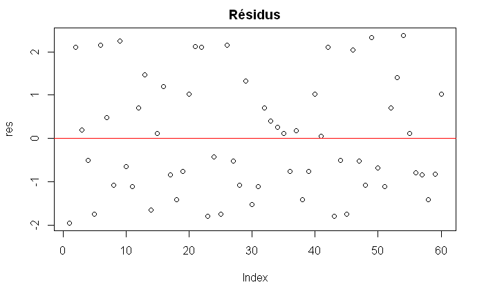

```r
res<-resid(NotesregMath)
plot(res,main="Résidus")
abline(h=0,col="red")
```

On peut aussi calculer la moyenne des résidus :

```r
mean(res)
```

```
[1] 8.326673e-18
```

On voit qu’elle est très proche de 0 et donc que les résidus sont répartis de manière homogène. D’autre part, summary(NotesregMath) nous montre une p-value très petite, ce qui indique que au test de significativité globale on peut rejeter l’hypothèse H0 et dire que le modèle est globalement significatif. On remarque que c’est moins le cas pour le modèle concernant l’EPS.

2. Visualisations 2.a Histogramme

```r
NotesEPS
```

```
 [1] 14 14 14  9 12  9  9 12 12 10 10 12 12 12 10 12 12 12 13 13 13 13 13  8  8  8 10 10 10 13 10 10 10 14 14 14 13 13 13 12 12 12 14 14 14 17
[47] 17 17 11 11 11 18 16 18  0  0  0 17 17 17
```

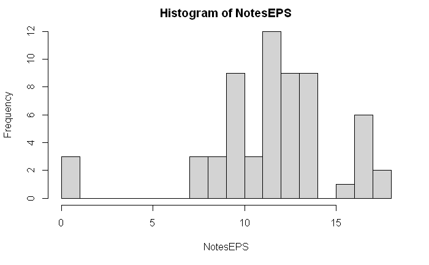

```r
hist(NotesEPS, breaks=20)
```

On peut afficher la PDF (fonction de densité) :

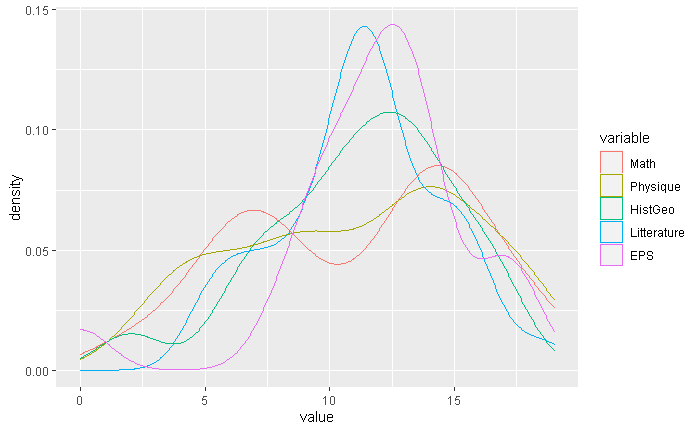

```r
library(ggplot2)
library(reshape2)
Notes.plot = melt(Notes)
p <- ggplot(aes(x=value, colour=variable), data=Notes.plot)
p + geom_density()
```

Pour afficher un ensemble d’histogrammes pour chaque dimension on utilisera le code :

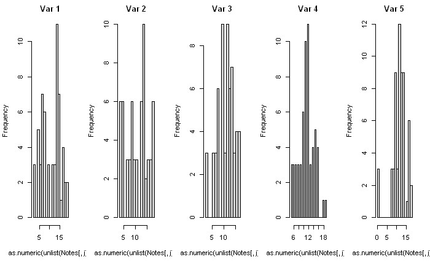

```r
par(mfrow=c(1,5))
for (j in 1:5) hist(as.numeric(unlist(Notes[,j])),breaks=20,main = paste("Var",j))
```

2.b Box Plot Sur une seule dimension (une seule variable aléatoire)

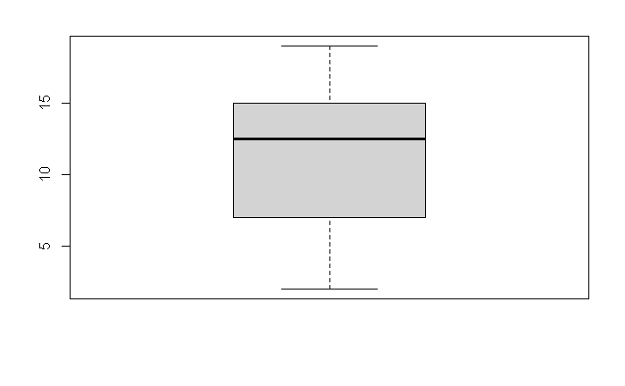

```r
boxplot(NotesMath)
```

Sur plusieur dimension, il est possible d’afficher un boxplot par dimension :

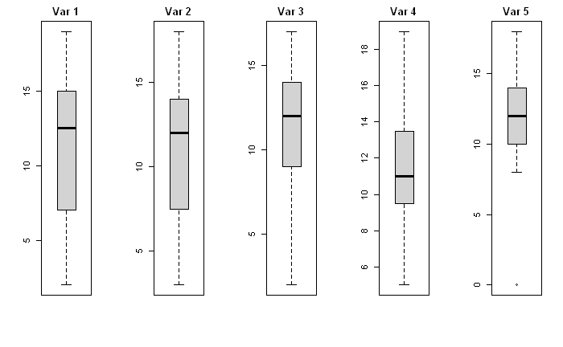

```r
par(mfrow=c(1,5))
for (j in 1:5) boxplot(as.numeric(unlist(Notes[,j])), main = paste("Var",j))
```

2. ScatterPlot Permet d’afficher une valeur de colonne en fonction d’une autre. Sur les données sur plusieur dimensions on peut les afficher sous forme matricielle :

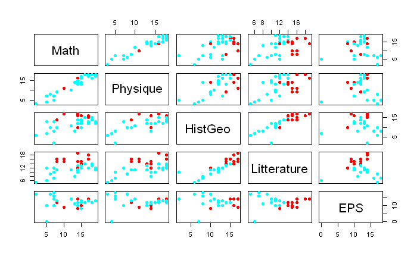

```r
zfac <- factor(Data$Genre)
mescouleurs <- rainbow(length(levels(zfac)))
plot(Notes,pch = 19,col=mescouleurs[zfac])
```

On peut retrouver la correlation ici entre les maths et la physique, ainsi qu’entre l’histoire geographie et la litterature

Note : Au cas où nous aurions besoin d’étudier la moyenne en fonction du genre :

```r
moyenne=c()

for (i in 1:length(row.names(Notes))){
moyenne<-c(moyenne,sum(Notes[i,])/length(Notes[i,]))
}

eleves = c(Data["Eleve"])
genre = c(Data["Genre"])
MoyenneNotes = data.frame(eleves,moyenne,genre)
MoyenneNotes
```

| Eleve | moyenne | Genre |
| --- | --- | --- |
| Eleve 30 | 16.0 | FILLE |
| Eleve 10 | 16.6 | FILLE |
| Eleve 50 | 16.0 | FILLE |
| Eleve 4 | 12.6 | FILLE |
| Eleve 59 | 11.8 | FILLE |
| Eleve 44 | 12.6 | FILLE |
| Eleve 24 | 12.4 | FILLE |
| Eleve 19 | 11.6 | FILLE |
| Eleve 39 | 11.6 | FILLE |
| Eleve 53 | 14.0 | FILLE |

[output cut: 50 more lines]

3. Machine Learning

3.1. Procédures de ML supervisé (X et Y sont connus)

3.1.a KNN

```r
library(class)
X = Data[,2:6]
Y = as.data.frame(Data[,7])
learn = sample(1:60,50) # sample 60 indexes of individuals that will be used in the learning set
train = X[learn,] # 50 obs for learning
cl = Y[learn,]
test = X[-learn,] # The remaining 10 obs for validation
Yreel = Y[-learn,]
?knn
Prediction = knn(train,test,cl,k = 4)
Resultat=data.frame(Data[-learn,],Prediction)
Resultat
```

| Eleve | Math | Physique | HistGeo | Litterature | EPS | Genre | Prediction |
| --- | --- | --- | --- | --- | --- | --- | --- |
| Eleve 30 | 14 | 16 | 17 | 19 | 14 | FILLE | FILLE |
| Eleve 13 | 15 | 14 | 16 | 14 | 10 | FILLE | FILLE |
| Eleve 56 | 17 | 18 | 13 | 12 | 13 | GARCON | GARCON |
| Eleve 47 | 14 | 14 | 10 | 12 | 8 | GARCON | GARCON |
| Eleve 20 | 14 | 13 | 12 | 11 | 10 | GARCON | GARCON |
| Eleve 51 | 8 | 9 | 10 | 11 | 13 | GARCON | GARCON |
| Eleve 57 | 14 | 15 | 12 | 10 | 12 | GARCON | GARCON |
| Eleve 38 | 13 | 14 | 8 | 8 | 11 | GARCON | GARCON |
| Eleve 35 | 5 | 4 | 7 | 6 | 0 | GARCON | GARCON |
| Eleve 48 | 2 | 3 | 6 | 5 | 17 | GARCON | GARCON |

```r
NA
```

On peut calculer la marge d’erreur :

```r
err = sum(Prediction != Yreel) / length(Yreel)
err
```

[output not shown]

Tentons d’améliorer ce résultat en utilisant la méthode V-fold cross validation (Plusieurs periodes d’apprentissage/test avec des échantillons différents)

```r
V = 20
fold = rep(1:V,nrow(X)/V)
for (v in 1:V){
  learn = which(fold != v)
  Xl = X[learn,] # 100 obs for learning
  Yl = Y[learn,]
  Xv = X[-learn,] # The remaining 50 obs for validation
  Yv = Y[-learn,]
  f = knn(Xl,Xv,Yl,k = 5)
  err[v] = sum(f != Yv) / length(Yv)
}
#err
mean(err)
```

```
[1] 0.09166667
```

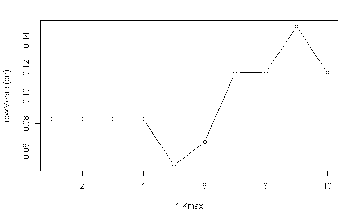

```r
Kmax = 10
V = 20
err = matrix(NA,Kmax,20)
fold = rep(1:V,nrow(X)/V)
for (v in 1:V){
  learn = which(fold != v)
  Xl = X[learn,]
  Yl = Y[learn,]
  Xv = X[-learn,]
  Yv = Y[-learn,]
  for (k in 1:Kmax){
    f = knn(Xl,Xv,Yl,k)
    err[k,v] = sum(f != Yv) / length(Yv)
  }
}
plot(1:Kmax,rowMeans(err),type='b')
```

Il semble que le K ayant le taux d’erreur le plus bas est de 5. Nous noterons ce parametre K* (ou Kstar), que nous pourrons utiliser pour prédire le genre d’un élève en fonction de ses notes.

Enfin, pour calculer l’estimation statistique de l’erreur globale, on applique la formule erreur moyenne +/- écart type :

```r
V = 20
fold = rep(1:V,nrow(X)/V)
for (v in 1:V){
  learn = which(fold != v)
  Xl = X[learn,] # 100 obs for learning
  Yl = Y[learn,]
  Xv = X[-learn,] # The remaining 50 obs for validation
  Yv = Y[-learn,]
  f = knn(Xl,Xv,Yl,k = 5)
  err[v] = sum(f != Yv) / length(Yv)
}
StatGlobErr=c((mean(err)-sd(err)),(mean(err)),(mean(err)+sd(err)))
StatGlobErr
```

```
[1] -0.05754492  0.09166667  0.24087826
```

```r
library(e1071)
DF = data.frame(Data$Math, Data$Litterature, as.factor(Data$Genre))
DF
```

| Data.Math | Data.Litterature | as.factor.Data.Genre. |
| --- | --- | --- |
| 14 | 19 | FILLE |
| 17 | 18 | FILLE |
| 17 | 16 | FILLE |
| 10 | 16 | FILLE |
| 8 | 16 | FILLE |
| 10 | 16 | FILLE |
| 10 | 15 | FILLE |
| 8 | 15 | FILLE |
| 8 | 15 | FILLE |
| 15 | 15 | FILLE |

[output cut: 50 more lines]

```r
summary(DF)
```

```
   Data.Math     Data.Litterature as.factor.Data.Genre.
 Min.   : 2.00   Min.   : 5.00    FILLE :14
 1st Qu.: 7.00   1st Qu.: 9.75    GARCON:46
 Median :12.50   Median :11.00
 Mean   :11.13   Mean   :11.30
 3rd Qu.:15.00   3rd Qu.:13.25
 Max.   :19.00   Max.   :19.00
```

[figure not shown]

```r
plot(DF$Data.Math,DF$Data.Litterature, col=DF$as.factor.Data.Genre, pch=16)
legend(2,17.9,legend=c("Garçon","Fille"),col=1:length(DF$as.factor.Data.Genre),lty=1:2)
```

Construction du classificateur SVM mlin :

```r
mlin <- svm(DF$as.factor.Data.Genre ~ DF$Data.Math+DF$Data.Litterature, data=DF, kernel="linear",scale=F)
print(mlin)
```

```
Call:
svm(formula = DF$as.factor.Data.Genre ~ DF$Data.Math + DF$Data.Litterature, data = DF, kernel = "linear", scale = F)


Parameters:
   SVM-Type:  C-classification
 SVM-Kernel:  linear
       cost:  1

Number of Support Vectors:  9
```

Mettons en évidence les “points supports” qui détermineront notre hyperplan SVM

```r
print((rownames(df))[mlin$index])
```

[output not shown]

```r
plot(DF$Data.Math,DF$Data.Litterature, col=DF$as.factor.Data.Genre, pch=16)
legend(2,17.9,legend=c("Garçon","Fille"),col=1:length(DF$as.factor.Data.Genre),lty=1:2)
```

[figure not shown]

```r
points(DF$Data.Math[mlin$index],DF$Data.Litterature[mlin$index],cex=3,col=rgb(0,0,0))
```

Nous pouvons maintenant représenter les frontières :

```r
beta.0 <- -mlin$rho
beta.1 <- sum(mlin$coefs*DF$Data.Math[mlin$index])
beta.2 <- sum(mlin$coefs*DF$Data.Litterature[mlin$index])
plot(DF$Data.Math,DF$Data.Litterature, col=DF$as.factor.Data.Genre, pch=16)
legend(2,17.9,legend=c("Garçon","Fille"),col=1:length(DF$as.factor.Data.Genre),lty=1:2)
```

[figure not shown]

```r
points(DF$Data.Math[mlin$index],DF$Data.Litterature[mlin$index],cex=3,col=rgb(0,0,0))
abline(-beta.0/beta.2,-beta.1/beta.2,col="green")
```

3.1.c LDA

```r
library(MASS)
X = Data[,2:6]
Y = as.data.frame(Data[,7])
learn = sample(1:60,50) # sample 60 indexes of individuals that will be used in the learning set
learn = sample(1:60,50) # sample 60 indexes of individuals that will be used in the learning set
train = X[learn,] # 50 obs for learning
cl = Y[learn,]
test = X[-learn,] # The remaining 10 obs for validation
Yreel = Y[-learn,]
f=lda(train,cl)
f
```

```
Call:
lda(train, cl)

Prior probabilities of groups:
 FILLE GARCON
  0.24   0.76

Group means:
           Math Physique  HistGeo Litterature      EPS
FILLE  13.08333 13.41667 15.16667   15.416667 11.16667
GARCON 10.65789 10.50000 10.18421    9.947368 11.89474

Coefficients of linear discriminants:
                    LD1
Math         0.10867001
Physique     0.03558773
HistGeo     -0.04991321
Litterature -0.50448343
EPS          0.04106295
```

```r
pred=predict(f,test)
sum(pred$class != Yreel) / length(Yreel)
```

```
[1] 0
```

3.2 Unsupervised learning

Le but de l’apprentissage non supervisé est de classifier une variable aléatoire sans avoir la correspondance pour apprentissage. En d’autre termes, on a X mais pas Y.

3.2.a PCA Le but ici est de réduire les dimensions d’une variable aléatoire. Cette méthode utilise la combinaison linéaire (operations matricielles, calculs de eigen values). Tout d’abord il faut “centraliser” les données, c’est à dire déplacer les axes d’origine pour qu’ils se croisent au “centre” des valeurs. Ensuite calculer une matice Sigma en fonction de la variable aléatoire “centralisée” et d’en extraire les premiers eigenvectors. On retiendra les d premiers eigenvectors comme réduction des dimensions de notre data frame.